# APSTA-GE 2003: Intermediate Quantitative Methods, Fall 2020

10/07/20

## Statistics Review

## What is Statistics about?

- Inference
  - **Correlation Inference**
  - Causal Inference

**Correlation:** make predictions based on the correlation of variables.

**Causation:** change of one variable leads to the change of another.

**Correlation does not lead to causation!**

## Correlation Inference

- On **Average**
  - individual level variation = error (\(\varepsilon\))
- Examine if `variable A` is associated with `variable B`
  - The change of `A` is connected with the change of `B`

## Hypothesis Testing

- Make an assumption
  - The higher the salt level, the higher the blood pressure.
  - Income level is associated with people’s height.
- Make hypotheses on mean difference
  - Null: no difference
  - Alternative: different
- Collect data and calculate summary statistics
  - Mean, variance, standard deviation
  - Calculate standard error
- Measure how sample points deviate from (imaginary) popluation mean
  - Use T-test
  - Calculate p-value (chance to accept null hypothesis)
    - if \(<0.05\), reject the null (**Significant difference**)
    - if \(\geq 0.05\), fail to reject the null

## Central Limit Theorem

**For large population size, sample mean follows a normal distribution**

\[ \overline{x} \sim \mathcal{N} (\mu, \frac{\sigma^2}{N}) \]

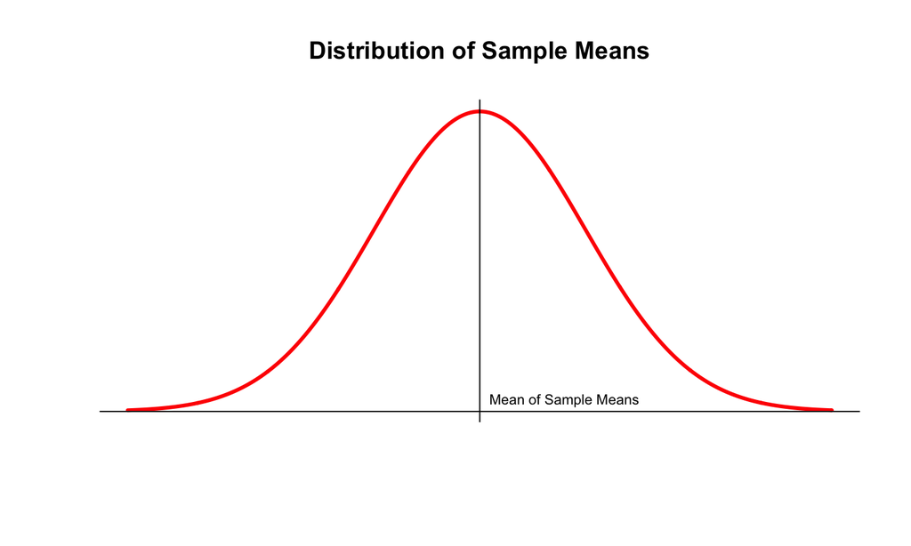

## Regression Analysis

- Make prediction based on T-test results
  - Dependent variable (DV) and independent variable (IV)
  - Use simple linear regression to predict DV based on IV (on avarage)
    - \(DV = \beta_0 + \beta_1 IV\)
    - \(\beta_0\): Intercept
    - \(\beta_1\): Slope

## Math Review

## Median

**The value at the center**

- For odd \(n\):

\[ X_\frac{n + 1}{2} \]

- For even \(n\):

\[ \frac{X_\frac{n}{2} + X_\frac{n+1}{2}}{2} \]

\(n\): Sample Size

## Mean

**The average value**

**Population Mean:**

\[ \mu = \frac{\sum_{i=1}^{N} X_i}{N} \]

**Sample Mean:**

\[ \overline{x} = \frac{\sum_{i=1}^{n} x_i}{n} \]

\(N\): Population Size, \(n\): Sample Size

## Variance

**Expected squared distance from the mean**

**Population Variance:**

\[ \sigma^2 = \frac{1}{N} \sum_{i=1}^{N} (x_i - \mu)^2 \]

**Sample Variance:**

\[ s^2 = \frac{1}{n-1} \sum_{i=1}^{n} (x_i - \overline{x})^2 \]

\(N\): Population Size, \(n\): Sample Size

## Standard Deviation (SD)

**Expected distance from the mean**

**Population SD:**

\[ \sigma = \sqrt {\text{Population Variance}} \]

**Sample SD:**

\[ s = \sqrt {\text{Sample Variance}} \]

## Standard Error (SE)

**Expected distance of sample means from population mean**

**Error: individual-level variation (noise)** In this case, error is the mean variation of each sample.

\[ SE = \sqrt{\frac{Var.}{n}} \]

\[ SE \downarrow = \frac{SD \downarrow}{\sqrt{n}} \\ SE \uparrow = \frac{SD \uparrow}{\sqrt{n}} \\ \]

## SE Demo

*Demo*

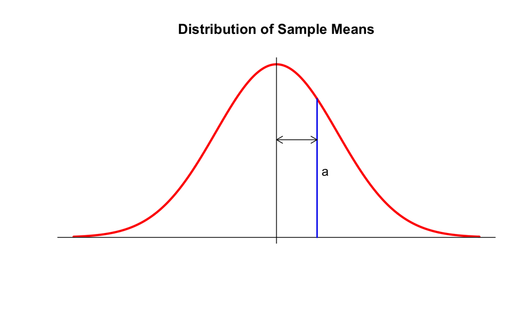

## Confidence Interval

**Estimated population mean**

with 95% of confidence, we estimate the population mean is within:

\[ (\overline{x} - 1.96 SE, \ \overline{x} + 1.96 SE) \]

## Pooled Variance

**Weighted average of the variance of two samples by degrees of freedom**

\[ s^2_{pooled} = \frac{Var_1 + Var_2}{n_1 - 1 + n_2 - 1} \]

## Degrees of Freedom (d.f.)

**The level of freedom that you can freely replace values**

\[ \begin{align*} A &= {5, 3, 4, 4} \\ &df_A = 4 \\ \\ \mu_A &= \frac{5 + 3 + 4 + 4}{4} = 4 \\ &df_{\mu_A} = 3 \\ \\ \sigma_A &= \frac{(5-4)^2+(3-4)^2+(4-4)^2+(4-4)^2}{df_{\mu_A}} = \frac{2}{3} \end{align*} \]

## Programming in R

## Levene’s Test

```r
install.packages("car") # Companion to Applied Regression
library(car)

# Demo
leveneTest(Time ~ factor(Gender), data = marathon)
```

## Simple Linear Regression

```r
lm1 <- lm(Time ~ Gender, data = marathon)
summary(lm1)
```

## Visualizing Linear Regression

```r
dat <- marathon
lm1 <- lm(Time ~ Gender, data = dat)
dat %>%
  plot_ly(x = ~Gender) %>%
  add_markers(y = ~Time) %>%
  add_lines(x = ~Gender, y = fitted(lm1))
```

[interactive chart not shown]

## Understanding Linear Regression Output

```r
summary(lm(Time ~ Gender, data = dat))
```

```
##
## Call:
## lm(formula = Time ~ Gender, data = dat)
##
## Residuals:
##      Min       1Q   Median       3Q      Max
## -0.15511 -0.09608 -0.06150 -0.01357  0.57850
##
## Coefficients:
##             Estimate Std. Error t value Pr(>|t|)
## (Intercept)  2.56622    0.03110  82.505  < 2e-16 ***
## Genderm     -0.34557    0.04362  -7.922 9.25e-11 ***
## ---
## Signif. codes:  0 '***' 0.001 '**' 0.01 '*' 0.05 '.' 0.1 ' ' 1
##
## Residual standard error: 0.1675 on 57 degrees of freedom
## Multiple R-squared:  0.5241, Adjusted R-squared:  0.5157
## F-statistic: 62.76 on 1 and 57 DF,  p-value: 9.248e-11
```

## Contact

Tong Jin

- Email: tj1061@nyu.edu
- Office Hours
  - Mondays, 9 - 10am (EST)
  - Wednesdays, 12:30 - 1:30pm (EST)